# Analysis Scores – One Sample t Test

```r
library(mosaic)
library(tidyverse)
library(car)
library(pander)
library(DT)

resub <- read_csv("../../../Data/analysisResubmitTimes.csv")
```

## Background

In the Math 325 Intermediate Statistics course at BYU-Idaho, the weekly analyses that students are required to complete make up a large portion of their grade in the class, 40% to be exact. One of the unique features of the course is that students are allowed to improve and resubmit their work, even after the deadline has passed. In fact, resubmissions are encouraged until students are awarded full credit. Ideally, students would resubmit within one day of receiving feedback on their analysis, but most teachers allow a week or two for resubmissions. The following looks to see how long students take on average to resubmit, and if it is significantly different from 7 days on average.

$$H_0: \mu_\text{resubmission days} = 7$$
$$H_a: \mu_\text{resubmission days} \neq 7$$

The significance level for this study will be set at $\alpha = 0.05$.

### Show Data

Data was selected by convenience sample from a teacher who did not have a deadline on when students could resubmit their analyses. Some students have missing values for `DaysToResubmit` and `FinalScore` because they never resubmit, or never submitted an analysis, respectively. So only the 18 students who both submit an analysis and resubmit their work will be included in this study.

```r
datatable(arrange(resub, desc(DaysToResubmit)))
```

|  | Student | DaysToResubmit | FinalScore |
| --- | --- | --- | --- |
| 1 | 28 | 62 | 15 |
| 2 | 29 | 62 | 11 |
| 3 | 26 | 59 | 14.75 |
| 4 | 27 | 59 | 15 |
| 5 | 24 | 51 | 15 |
| 6 | 25 | 51 | 14.2 |
| 7 | 23 | 49 | 12 |
| 8 | 22 | 48 | 15 |
| 9 | 21 | 42 | 15 |
| 10 | 20 | 41 | 15 |

[output cut: 19 more lines]

## Analysis

Somewhat surprisingly, the average days to resubmit the t Test analysis is a little over a month at 35.2 days (of those who choose to resubmit). The fastest resubmission was 7 days after the original feedback was given.

*Note that only the last resubmission time was recorded. A few students resubmit several times before their final resubmission, and those intermediate resubmissions were not recorded.*

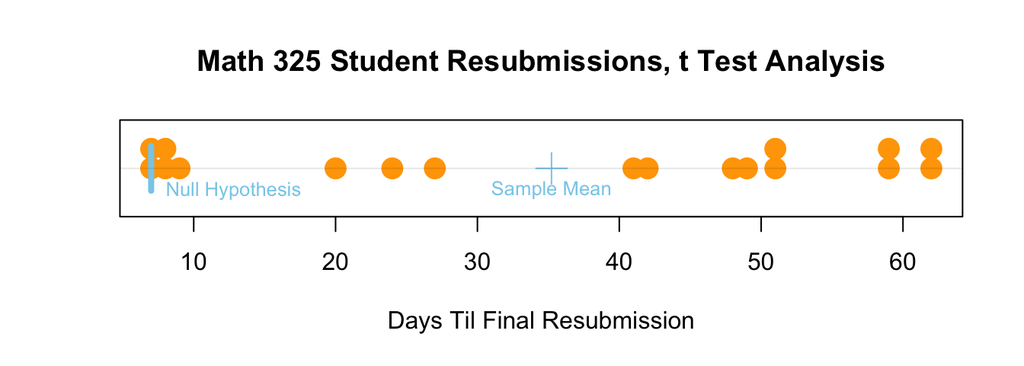

```r
stripchart(resub$DaysToResubmit, pch=16, method="stack", cex=2, col="orange", main="Math 325 Student Resubmissions, t Test Analysis", xlab="Days Til Final Resubmission")
lines(c(7,7), c(0.5,1.5), lty=1, col="skyblue", lwd=4)
points(mean(resub$DaysToResubmit, na.rm=TRUE), 1, pch=3, cex=2, col="skyblue")
text(mean(resub$DaysToResubmit, na.rm=TRUE), 1, "Sample Mean", pos=1, cex=0.8, col="skyblue")
text(7,0.5, "Null Hypothesis", pos=4, col="skyblue", cex=0.8)
abline(h=1, col=rgb(.1,.1,.1,.1))
```